# Predicting the risk of death

Author

Alexsander R. Carvalho Junior

Published

January 7, 2026

# Objective

The objective of this project is to develop a machine learning model to estimate the probability of in-hospital mortality at the time of admission for hospitalizations due to Primary Care Sensitive Conditions (PCSCs / ICSAPs) in Brazil.

The model aims to support early risk classification by identifying patients with a higher probability of death based solely on information available at admission.

# Methodology

The methodological approach follows the SEMMA framework (Sample, Explore, Modify, Model, and Assess).

The analytical base table was created with hospital admission data from 2022 to 2024. In the Sample phase the dataset will be splited into training, test, and an ou-of-time (oot) validation set. During Explore, bivariate analyses will be conducted to evaluate the relationship between each predictor and the outcome. In the Modify phase, categorical variables were encoded using a combination of encoding tools from `feature-engine` package. In the Model step, different machine learning algorithms based on boosting and bagging strategies will be compared, evaluated using weighted F1-score and ROC-AUC. Finally, in the Assess phase, model performance will be evaluated on the OOT set. We are going to use SHAP values to interpret the model’s predictions, allowing both global understanding of feature importance and local explanation of individual risk scores.

# Getting satrted

First, we import some modules that will be used.

```python
from pathlib import Path
import duckdb
import pandas as pd
import numpy as np
import re
import time
import joblib

import matplotlib.pyplot as plt
import seaborn as sns
from pypalettes import load_cmap

from feature_engine.encoding import MeanEncoder
from feature_engine.encoding import OneHotEncoder
from feature_engine.selection import DropFeatures

from sklearn.model_selection import train_test_split
from sklearn.base import BaseEstimator, TransformerMixin
from sklearn.pipeline import Pipeline
from sklearn.ensemble import RandomForestClassifier
from sklearn.model_selection import RandomizedSearchCV

from sklearn.metrics import f1_score, roc_auc_score, roc_curve
from sklearn.metrics import ConfusionMatrixDisplay

from imblearn.ensemble import BalancedBaggingClassifier
from imblearn.ensemble import BalancedRandomForestClassifier

import xgboost as xgb
import lightgbm as lgb

import shap
```

The analytical base table was created and stored as a .parquet file. We can use `duckdb` to read and load the data.

```python
# define base dir and data directories
base_dir = Path.cwd().parent.parent
data_file = base_dir / "data" / "tables_gold" / "sih_sus_abt.parquet"
```

```python
# count the number of records in the dataset
count = duckdb.sql(f"""
SELECT COUNT(*) FROM read_parquet('{data_file}')
""").fetchone()[0]

print(f"The dataset has {count} records.")
```

```
The dataset has 3133759 records.
```

# SEMMA

## Sample

Here, we define the OOT table and the dataset that will be further split into training and test sets.

```python
# query the out of time data set
oot = duckdb.sql(f"""
SELECT * FROM read_parquet('{data_file}')
WHERE year = 2024 AND month >= 7
""").df()

# query the data for train and test
df = duckdb.sql(f"""
SELECT * FROM read_parquet('{data_file}')
WHERE (year < 2024)
  OR (year = 2024 AND month <=6)
""").df()
```

```python
df.head()
```

|  | id_hospitalization | year | month | big_region_name | gender | age | disease_category | bed_speciality | complexity | procedure | total_hosp_days | death_flag |
| --- | --- | --- | --- | --- | --- | --- | --- | --- | --- | --- | --- | --- |
| 0 | 3122124819320 | 2022 | 11 | Sudeste | Female | 32 | Pneumonias bacterianas | cirurgia geral | media complexidade | tratamento de pneumonias ou influenza (gripe) | 12 | 0 |
| 1 | 3122123254580 | 2022 | 6 | Sudeste | Male | 45 | Deficiências Nutricionais | cirurgia geral | media complexidade | tratamento de acidente vascular cerebral - avc... | 7 | 0 |
| 2 | 4222104209170 | 2022 | 5 | Sul | Female | 92 | Infecção no Rim e Trato Urinário | cirurgia geral | media complexidade | tratamento de outras doencas do aparelho urinario | 8 | 0 |
| 3 | 3122151992333 | 2022 | 12 | Sudeste | Female | 78 | Doenças Cerebrovasculares | cirurgia geral | media complexidade | tratamento de acidente vascular cerebral - avc... | 3 | 1 |
| 4 | 2322103687904 | 2022 | 9 | Nordeste | Female | 80 | Úlcera gastrointestinal | cirurgia geral | media complexidade | tratamento de outras doencas do aparelho diges... | 4 | 0 |

Temporal features like `year`and `month` won’t be used. The target variable for the classification task is `death_flag` (denoted as y), while the remaining variables are used as predictive features (X).

```python
# define explanatory features and the target
features = df.columns[3:-1]
target = "death_flag"

X, y = df[features], df[target]
```

Before random split the data, we can check the mean values of the target classes.

```python
print(f"{100*(y.value_counts(normalize=True)[0]):.1f}% of the target values are from the class 0")
print(f"{100*(y.value_counts(normalize=True)[1]):.1f}% of the target values are from the class 1")
```

```
92.4% of the target values are from the class 0
7.6% of the target values are from the class 1
```

The target variable is clearly imbalanced! However we continue with a random train/test split with an 80:20 ratio.

```python
# random split the data into train (80%) and test (20%) set
# stratify by the target
X_train, X_test, y_train, y_test = train_test_split(X, y,
                                                    random_state=42,
                                                    test_size=0.2,
                                                    stratify=y)
```

```python
print(f"Training set has {y_train.shape[0]} obs. and a target variable rate of {100*y_train.mean():.2f}%")
print(f"Test set has {y_test.shape[0]} obs. and a target variable rate of {100*y_test.mean():.2f}%")
```

```
Training set has 2063898 obs. and a target variable rate of 7.56%
Test set has 515975 obs. and a target variable rate of 7.56%
```

```python
# displaying sizes of train/test features and labels
print("Training features shape:", X_train.shape)
print("Training labels shape:", y_train.shape)
print("Testing features shape:", X_test.shape)
print("Testing features shape:", y_test.shape)
```

```
Training features shape: (2063898, 8)
Training labels shape: (2063898,)
Testing features shape: (515975, 8)
Testing features shape: (515975,)
```

## Explore

To explore the data, we merge the training features and target temporarily.

```python
# merge the X and y train only for exploratory analysis
df_train = X_train.copy()
df_train[target] = y_train.copy()
```

First, check for missing values (NA).

```python
df_train.isna().sum()
```

```
big_region_name     0
gender              0
age                 0
disease_category    0
bed_speciality      0
complexity          0
procedure           0
total_hosp_days     0
death_flag          0
dtype: int64
```

Nice, no NA values are found in the dataset.

### Bivariate analysis

```python
# define theme and palette used for plots
cmap = load_cmap("Color_Blind")
sns.set_theme(style="white", palette=cmap.colors)
```

The only nummeric features in the data set are `age` and `total_hosp_days`. We can explore their descriptive statistic to better understand their distributions.

```python
age_summary = (
  df_train.groupby(by="death_flag")["age"]
          .agg(
            mean = "mean",
            median = "median",
            std = "std"
          )
          .reset_index()
)
age_summary
```

|  | death_flag | mean | median | std |
| --- | --- | --- | --- | --- |
| 0 | 0 | 49.957135 | 57.0 | 28.118973 |
| 1 | 1 | 70.714459 | 74.0 | 17.428397 |

There are some differences in age distribution between patients who survived (0) and those who died (1) during hospitalization. The mean age is approximately 50 years for the ones how lived, with a median of 57, and a relatively high standard deviation, indicating wide variability in ages. In contrast, patients who died have a significantly higher mean age of about 71 years, with a median of 74, and a lower standard deviation, suggesting that deaths are more concentrated in older age groups.

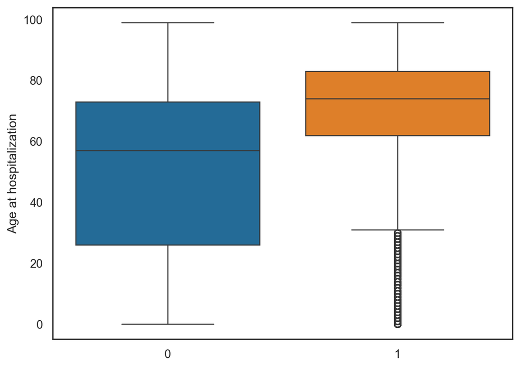

(a) Distribution os Deaths by Age at Hospitalization

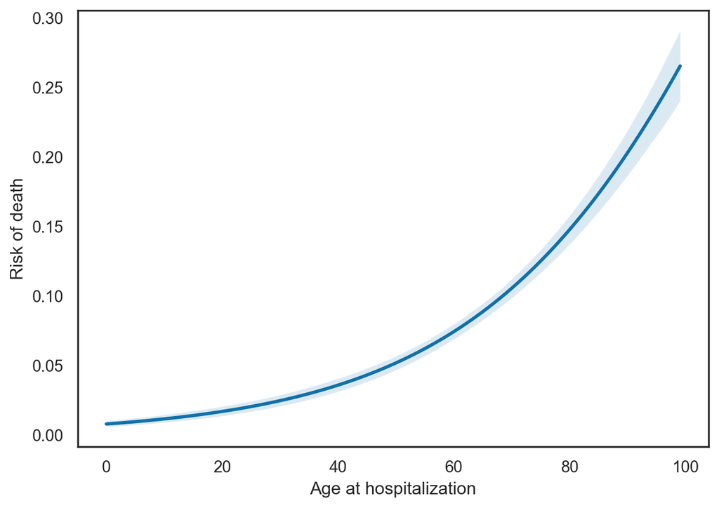

(b) Risk of Death by Age at Hospitalization

Figure 1: Impact of age on mortality risk

```python
# boxplot
fig, ax = plt.subplots()

sns.boxplot(
  data=df_train,
  x="death_flag", y="age",
  hue="death_flag", legend=False
)
ax.set_ylabel("Age at hospitalization")
ax.set_xlabel("")
plt.tight_layout()

# regplot
# get a subset of the data
n = df_train.sample(frac=0.005)

fig, ax = plt.subplots()

sns.regplot(
    x='age',
    y='death_flag',
    data=n,
    logistic=True,
    scatter=False
)
ax.set_xlabel("Age at hospitalization")
ax.set_ylabel("Risk of death")
plt.tight_layout()
```

Age appears to be a good predictor and may help distinguish between high- and low-risk patients. However, the relationship between age and mortality risk is not linear.

Now we can look for the days of hospitalization.

```python
hosp_days_summary = (
  df_train.groupby(by="death_flag")["total_hosp_days"]
          .agg(
            mean = "mean",
            median = "median",
            std = "std"
          )
          .reset_index()
)
hosp_days_summary
```

|  | death_flag | mean | median | std |
| --- | --- | --- | --- | --- |
| 0 | 0 | 6.073998 | 4.0 | 7.202288 |
| 1 | 1 | 8.378278 | 5.0 | 10.137956 |

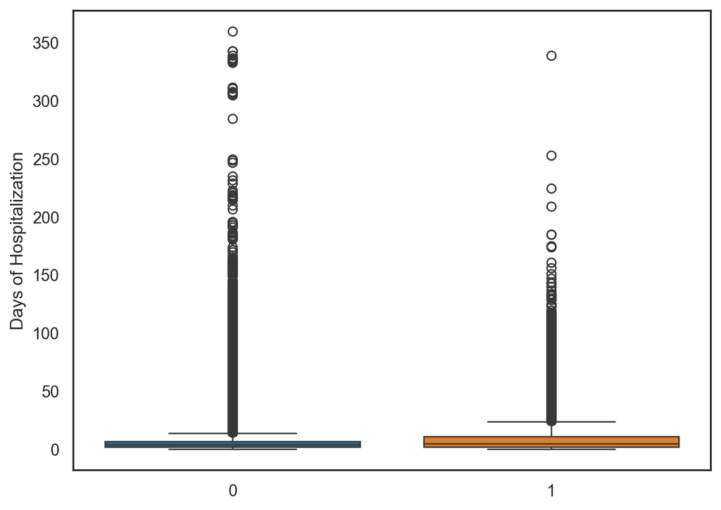

(a) Distribution os Deaths by Total Days of Hospitalization

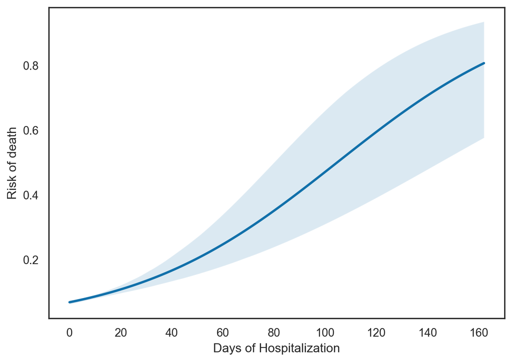

(b) Risk of Death by Days of Hospitalization

Figure 2: Impact of the total hosp. days on mortality risk

```python
# boxplot
fig, ax = plt.subplots()

sns.boxplot(
  data=df_train,
  x="death_flag", y="total_hosp_days",
  hue="death_flag", legend=False
)
ax.set_ylabel("Days of Hospitalization")
ax.set_xlabel("")
plt.tight_layout()

# regplot
fig, ax = plt.subplots()

sns.regplot(
    x='total_hosp_days',
    y='death_flag',
    data=n,
    logistic=True,
    scatter=False
)
ax.set_xlabel("Days of Hospitalization")
ax.set_ylabel("Risk of death")
plt.tight_layout()
```

There is substantial variability in the length of hospital stay among both survivors and non-survivors. The presence of outliers and the non-linear pattern suggest that length of stay colud be associate with different complex clinical processes rather than acting as a simple risk factor. For this reason, we can try to adress more value for this feature by aggregating it with other features.

Let’s have a look into the categorical features.

Given the large number of categorical variables, we can create helper functions to automate repetitive exploratory tasks.

```python
# define a function for summarise categoric features
def summary(df, by, sort):
  return(
    df.groupby(by)["death_flag"]
      .agg(
          death_rate = "mean",
          total_deaths = "sum",
          total_obs = "count",
          )
      .sort_values(by=sort, ascending=False)
      .reset_index()
  )
```

```python
# function for plot categorical features
def plot_count_rate(df, x, y, order):
  order = order[x]

  fig, ax = plt.subplots()

  sns.barplot(
    data=df,
    x=x, y=y, hue=x,
    order=order, hue_order=order
  )
  ax.spines[["right", "top", "left"]].set_visible(False)
  ax.yaxis.set_visible(False)
  ax.set_xlabel("")

  return ax
```

Among the categorical features, `big_region_name`and `disease_category` were already binned from their original representations to reduce cardinality.

```python
# summary of total and rate of death by region
region_summary = summary(df_train, by="big_region_name", sort="total_deaths")

# summary of total and rate of death by gender
gender_summary = summary(df_train, by="gender", sort="total_deaths")

# summary of total and rate of death by hosp. complexity
complexity_summary = summary(df_train, by="complexity", sort="total_deaths")
```

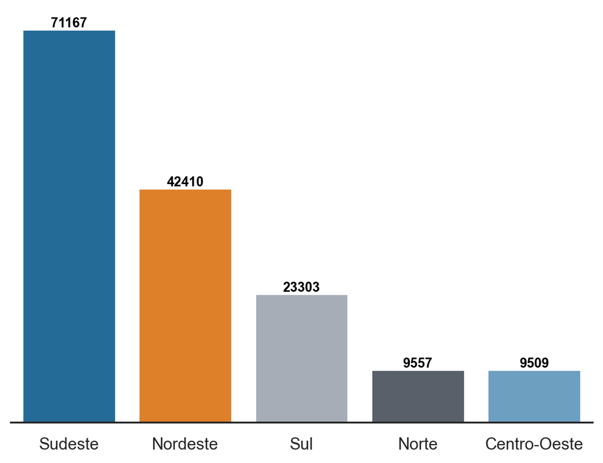

(a) Total of Deaths by Brazilian Regions

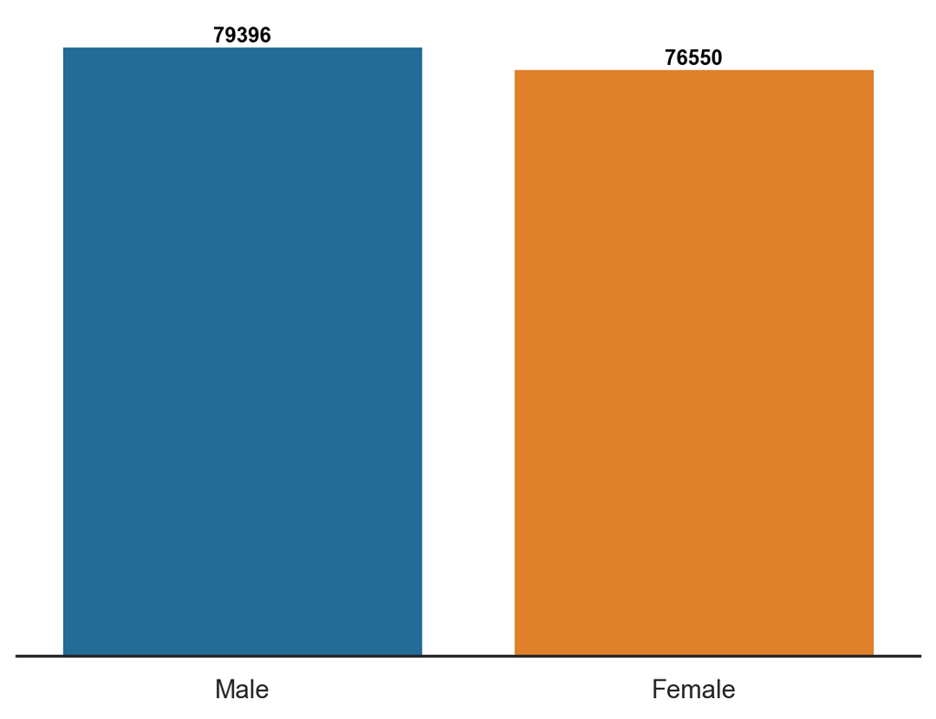

(b) Total of Deaths by Sex

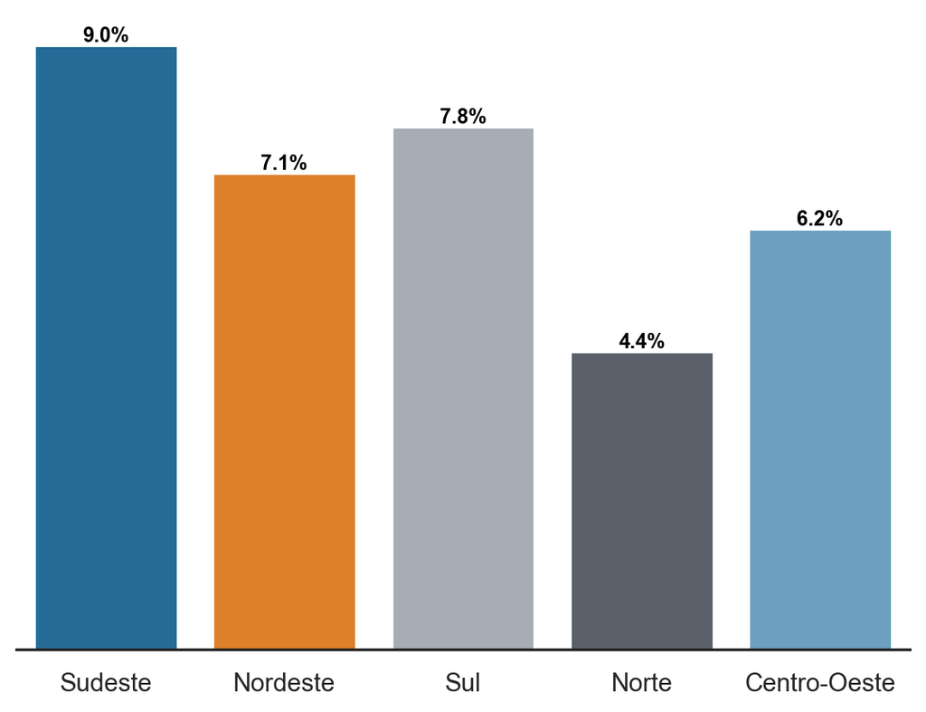

(c) Rate of Death by Brazilian Regions

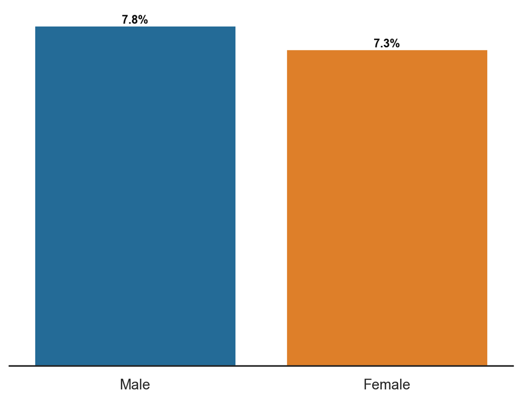

(d) Rate of Deaths by Sex

```python
# plot for the number of deaths
# by region
ax = plot_count_rate(region_summary, x="big_region_name", y="total_deaths", order=region_summary)
for container in ax.containers:
    ax.bar_label(container, fontsize=9, color='black', fontweight='bold')

# by gender
ax = plot_count_rate(gender_summary, x="gender", y="total_deaths", order=gender_summary)
for container in ax.containers:
    ax.bar_label(container, fontsize=9, color='black', fontweight='bold')

# plot for the rate of death
# by region
ax = plot_count_rate(region_summary, x="big_region_name", y="death_rate", order=region_summary)
for container in ax.containers:
    ax.bar_label(container, fmt=lambda x: f'{x * 100:.1f}%', fontsize=9, color='black', fontweight='bold')

# by gender
ax = plot_count_rate(gender_summary, x="gender", y="death_rate", order=gender_summary)
for container in ax.containers:
    ax.bar_label(container, fmt=lambda x: f'{x * 100:.1f}%', fontsize=9, color='black', fontweight='bold')
```

Mortality rates show variation across the major regions of the country. These differences suggest that regional factors may influence in-hospital mortality, potentially reflecting disparities in population health profiles, healthcare access, or clinical resource availability.

Gender, on the other hand, shows only minimal differences in mortality between males and females and is therefore expected to contribute little on its own.

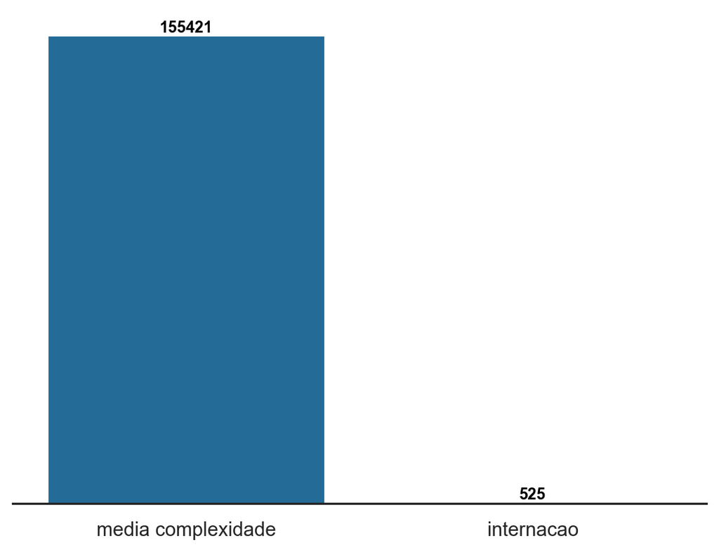

(a) Total of Deaths by the Type of Complexity

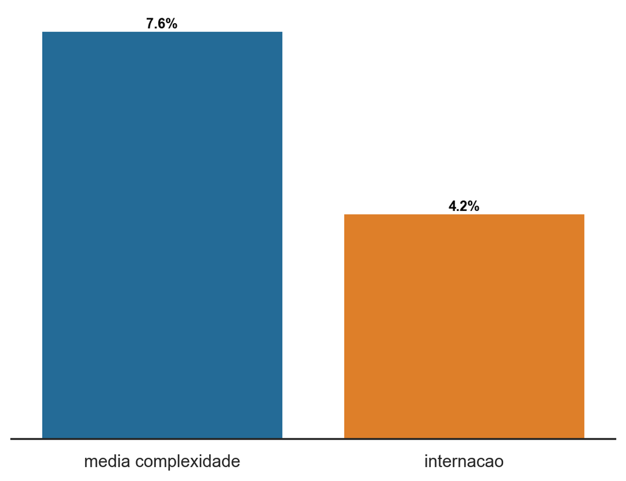

(b) Rate of Death by the Type of Complexity

Figure 4: Impact of hospitalization complexity on mortality risk

```python
# plot for the number of deaths and rate of hosp complexity
# total
ax = plot_count_rate(complexity_summary, x="complexity", y="total_deaths", order=complexity_summary)
for container in ax.containers:
    ax.bar_label(container, fontsize=9, color='black', fontweight='bold')

# rate
ax = plot_count_rate(complexity_summary, x="complexity", y="death_rate", order=complexity_summary)
for container in ax.containers:
    ax.bar_label(container, fmt=lambda x: f'{x * 100:.1f}%', fontsize=9, color='black', fontweight='bold')
```

Care complexity shows a clear difference in mortality across categories, suggesting it provides a coarse but relevant signal of patient acuity.

Next, we explore `disease_category`, `bed_speciality` and `procedure`.

```python
# summary of total and rate of death by disease category
disease_summary = summary(df_train, by="disease_category", sort="death_rate")
disease_summary
```

|  | disease_category | death_rate | total_deaths | total_obs |
| --- | --- | --- | --- | --- |
| 0 | Insuficiência Cardíaca | 0.182003 | 9025 | 49587 |
| 1 | Doenças Cerebrovasculares | 0.143424 | 55156 | 384567 |
| 2 | Deficiências Nutricionais | 0.136563 | 5613 | 41102 |
| 3 | Úlcera gastrointestinal | 0.112010 | 10262 | 91617 |
| 4 | Pneumonias bacterianas | 0.101155 | 32373 | 320033 |
| 5 | Doenças preveníveis por imunização e condições... | 0.098951 | 3508 | 35452 |
| 6 | Infecção no Rim e Trato Urinário | 0.047903 | 19377 | 404507 |
| 7 | Anemia | 0.041311 | 63 | 1525 |
| 8 | Diabetes melitus | 0.040428 | 10888 | 269318 |
| 9 | Infecção da pele e tecido subcutâneo | 0.028368 | 3027 | 106705 |
| 10 | Doencas pulmonares | 0.024763 | 1107 | 44704 |
| 11 | Eplepsias | 0.023342 | 57 | 2442 |
| 12 | Gastroenterites Infecciosas e complicações | 0.018888 | 3951 | 209179 |
| 13 | Hipertensão | 0.017187 | 1346 | 78317 |
| 14 | Angina | 0.016430 | 44 | 2678 |
| 15 | Asma | 0.008461 | 119 | 14064 |
| 16 | Infecções de ouvido, nariz e garganta | 0.006028 | 20 | 3318 |
| 17 | Doença Inflamatória órgãos pélvicos femininos | 0.002177 | 4 | 1837 |
| 18 | Doenças relacionadas ao Pré-Natal e Parto | 0.002037 | 6 | 2946 |

Disease category is one of the most informative features, with very large mortality differences between conditions like heart failure, cerebrovascular disease, nutritional deficiencies, and lower-risk infectious or chronic conditions. Together, these variables encode direct information about the clinical scenario and should contribute to the model’s ability to separate outcomes.

```python
# summary of total and rate of death by bed speciality
speciality_summary = summary(df_train, by="bed_speciality", sort="death_rate")
speciality_summary
```

|  | bed_speciality | death_rate | total_deaths | total_obs |
| --- | --- | --- | --- | --- |
| 0 | neurocirurgia | 0.558887 | 261 | 467 |
| 1 | endocrinologia | 0.156513 | 316 | 2019 |
| 2 | cirurgia geral | 0.089775 | 148683 | 1656165 |
| 3 | ginecologia | 0.085572 | 723 | 8449 |
| 4 | buco maxilo facial | 0.060487 | 4554 | 75289 |
| 5 | cirurgico/diagnostico/terapeutico | 0.004433 | 1409 | 317859 |
| 6 | aids | 0.000000 | 0 | 8 |
| 7 | cardiologia | 0.000000 | 0 | 3172 |
| 8 | gastroenterologia | 0.000000 | 0 | 37 |
| 9 | geriatria | 0.000000 | 0 | 53 |
| 10 | intercorrencia pos-transplante | 0.000000 | 0 | 23 |
| 11 | nefrologiaurologia | 0.000000 | 0 | 2 |
| 12 | obstetricia cirurgica | 0.000000 | 0 | 34 |
| 13 | oncologia | 0.000000 | 0 | 86 |
| 14 | ortopediatraumatologia | 0.000000 | 0 | 225 |
| 15 | otorrinolaringologia | 0.000000 | 0 | 10 |

Bed specialty exhibits substantial heterogeneity! Neurosurgery beds have very high mortality, while some specialties report none. Also, there are categories with a large number of records and others wir few.

```python
# summary of total and rate of death by procedure
procedures_summary = summary(df_train, by="procedure", sort="death_rate")
procedures_summary
```

|  | procedure | death_rate | total_deaths | total_obs |
| --- | --- | --- | --- | --- |
| 0 | reducao incruenta disjuncao / luxacao / fratur... | 1.0 | 1 | 1 |
| 1 | ponte-tromboendarterectomia aorto-iliaca | 1.0 | 1 | 1 |
| 2 | osteotomia da mandibula em paciente com anomal... | 1.0 | 1 | 1 |
| 3 | enucleacao de globo ocular | 1.0 | 1 | 1 |
| 4 | esfincterotomia interna e tratamento de fissur... | 1.0 | 1 | 1 |
| ... | ... | ... | ... | ... |
| 1001 | oclusao percutanea endovascular de arteria / veia | 0.0 | 0 | 4 |
| 1002 | ooforectomia / ooforoplastia | 0.0 | 0 | 28 |
| 1003 | orquidopexia bilateral | 0.0 | 0 | 1 |
| 1004 | orquidopexia unilateral | 0.0 | 0 | 2 |
| 1005 | vulvectomia total ampliada c/ linfadenectomia ... | 0.0 | 0 | 1 |

1006 rows × 4 columns

Many procedures show mortality rates of 100% or 0% simply because they occur only once or twice, which can mislead model training. To handle this, rare and true zero categories should be adressed. Once this is done, procedure type can be a good indicator of severity and clinical complexity, and is likely to be one of the top contributors in the model.

Some bed speciality and procedures categories have zero cases of death and rare number of observations (<= 100). We therefore aggregate these categories to capture true zero death cases and reduce noise from rare events. By doing this we can reduce the cardinality of these features, specialy for `procedure`.

For example, procedures categories with fewer than or equal to 100 observations are considered rare cases, while those with fewer than or equal to 1000 observations are treated as few cases.

```python
# filter for zero risk procedures
procedures_zero_risk = procedures_summary[
  (procedures_summary["total_deaths"] == 0) &
  (procedures_summary["total_obs"] > 100)]["procedure"].tolist()

# filter for procedures with few cases
procedures_few_cases = procedures_summary[
  (procedures_summary["total_deaths"] > 0) &
  (procedures_summary["total_obs"] > 100) &
  (procedures_summary["total_obs"] <= 1000)]["procedure"].tolist()

# filter for procedures with rare cases
procedures_rare_cases = procedures_summary[
  (procedures_summary["total_obs"] <= 100)]["procedure"].tolist()
```

```python
# apply the list of filters for procedures
df_train["procedure"] = np.where(
  df_train["procedure"].isin(procedures_zero_risk),
  "zero risk", df_train["procedure"]
)
df_train["procedure"] = np.where(
  df_train["procedure"].isin(procedures_few_cases),
  "few cases", df_train["procedure"]
)
df_train["procedure"] = np.where(
  df_train["procedure"].isin(procedures_rare_cases),
  "rare cases", df_train["procedure"]
)
```

```python
procedure_transformed = summary(
  df_train, by="procedure", sort="death_rate")

procedure_transformed
```

|  | procedure | death_rate | total_deaths | total_obs |
| --- | --- | --- | --- | --- |
| 0 | tratamento clinico de paciente oncologico | 0.195931 | 549 | 2802 |
| 1 | tratamento de edema agudo de pulmao | 0.192840 | 7110 | 36870 |
| 2 | toracostomia com drenagem pleural fechada | 0.162670 | 563 | 3461 |
| 3 | tratamento de insuficiencia renal aguda | 0.159037 | 469 | 2949 |
| 4 | tratamento de intercorrencias clinicas de paci... | 0.153177 | 352 | 2298 |
| 5 | tratamento de acidente vascular cerebral - avc... | 0.147346 | 52179 | 354125 |
| 6 | tratamento de desnutricao | 0.139189 | 5340 | 38365 |
| 7 | tratamento de insuficiencia cardiaca | 0.130330 | 1354 | 10389 |
| 8 | embolizacao arterial de hemorragia digestiva (... | 0.130282 | 148 | 1136 |
| 9 | tratamento da doenca renal cronica - drc | 0.124031 | 144 | 1161 |
| 10 | tratamento de infarto agudo do miocardio | 0.123902 | 127 | 1025 |
| 11 | diagnostico e/ou atendimento de urgencia em cl... | 0.120603 | 336 | 2786 |
| 12 | tratamento do acidente vascular cerebral isque... | 0.117324 | 235 | 2003 |
| 13 | tratamento de outras doencas do aparelho diges... | 0.110731 | 8927 | 80619 |
| 14 | tratamento de pneumonias ou influenza (gripe) | 0.101335 | 29733 | 293412 |
| 15 | tratamento de outras doencas do aparelho respi... | 0.100716 | 394 | 3912 |
| 16 | tratamento de tuberculose (a15 a a19) | 0.095836 | 2504 | 26128 |
| 17 | few cases | 0.084706 | 2776 | 32772 |
| 18 | amputacao / desarticulacao de membros inferiores | 0.079435 | 1124 | 14150 |
| 19 | rare cases | 0.074660 | 708 | 9483 |
| 20 | tratamento de crises epileticas nao controladas | 0.071199 | 199 | 2795 |
| 21 | tratamento de doencas do esofago estomago e du... | 0.071114 | 194 | 2728 |
| 22 | tratamento de anemias nutricionais | 0.066836 | 79 | 1182 |
| 23 | tratamento de disturbios metabolicos | 0.065689 | 1927 | 29335 |
| 24 | tratamento de outras doencas bacterianas | 0.058002 | 4174 | 71963 |
| 25 | tratamento de outras doencas do intestino | 0.057238 | 155 | 2708 |
| 26 | tratamento c/ cirurgias multiplas | 0.055083 | 440 | 7988 |
| 27 | tratamento de outras doencas do aparelho urinario | 0.052873 | 14265 | 269799 |
| 28 | tratamento de complicacoes de procedimentos ci... | 0.052277 | 101 | 1932 |
| 29 | tratamento de diabetes mellitus | 0.047255 | 7243 | 153276 |
| 30 | diagnostico e/ou atendimento de urgencia em cl... | 0.044486 | 1904 | 42800 |
| 31 | tratamento de outras afeccoes da pele e do tec... | 0.032913 | 107 | 3251 |
| 32 | tratamento de doencas renais tubulo-intersticiais | 0.030140 | 112 | 3716 |
| 33 | tratamento da pielonefrite | 0.029595 | 2950 | 99679 |
| 34 | tratamento de outras doencas causadas por viru... | 0.028765 | 72 | 2503 |
| 35 | debridamento de ulcera / de tecidos desvitaliz... | 0.026570 | 124 | 4667 |
| 36 | tratamento de pe diabetico complicado | 0.024604 | 1308 | 53163 |
| 37 | amputacao / desarticulacao de pe e tarso | 0.021891 | 135 | 6167 |
| 38 | tratamento das doencas cronicas das vias aerea... | 0.021435 | 990 | 46186 |
| 39 | tratamento de estafilococcias | 0.021047 | 478 | 22711 |
| 40 | tratamento de estreptococcias | 0.020394 | 497 | 24370 |
| 41 | tratamento de hipertensao secundaria | 0.018610 | 34 | 1827 |
| 42 | tratamento de crise hipertensiva | 0.015636 | 1048 | 67025 |
| 43 | internacao domiciliar | 0.015476 | 34 | 2197 |
| 44 | tratamento de intercorrencia pos-transplante d... | 0.014802 | 43 | 2905 |
| 45 | tratamento de infeccoes agudas das vias aereas... | 0.014695 | 19 | 1293 |
| 46 | tratamento de enterites e colites nao infecciosas | 0.013029 | 20 | 1535 |
| 47 | tratamento de doencas infecciosas intestinais | 0.011718 | 1921 | 163939 |
| 48 | amputacao / desarticulacao de dedo | 0.011593 | 174 | 15009 |
| 49 | tratamento de doencas inflamatorias dos orgaos... | 0.010825 | 16 | 1478 |
| 50 | tratamento de outras infeccoes agudas das vias... | 0.008754 | 79 | 9024 |
| 51 | tratamento de infeccoes especificas do periodo... | 0.004955 | 5 | 1009 |
| 52 | diagnostico e/ou atendimento de urgencia em cl... | 0.002072 | 26 | 12549 |
| 53 | tratamento de intercorrencias clinicas na grav... | 0.000223 | 1 | 4488 |
| 54 | zero risk | 0.000000 | 0 | 6855 |

As a result, the number of procedure categories is reduced from 1,006 to 55, causing more reliable mortality estimates.

## Modify

At this stage, we create two custom transformers to apply these aggregations consistently across the training and test sets.

```python
# custom transformer to transform bed speciality feature
# create the summary, define the filters and apply them to the dataset
class SpecialityGrouper(BaseEstimator, TransformerMixin):
  def __init__(self, target_col="death_flag"):
    self.target_col = target_col
    self.zero_risk_ = []
    self.few_cases_ = []
    self.rare_cases_ = []

  def fit(self, X, y):
    df_temp = X.copy()
    df_temp[self.target_col] = y

    # create the summary
    summary = df_temp.groupby("bed_speciality")[self.target_col].agg([
      'sum', 'count'])
    summary.columns = ['total_deaths', 'total_obs']

    # define the filters
    self.zero_risk_ = summary[
      (summary["total_deaths"] == 0) & (summary["total_obs"] > 100)
    ].index.tolist()

    self.few_cases_ = summary[
      (summary["total_deaths"] > 0) & (summary["total_obs"] > 100) &
      (summary["total_obs"] <= 3000)
    ].index.tolist()

    self.rare_cases_ = summary[
      (summary["total_obs"] <= 100)
    ].index.tolist()

    return self

  def transform(self, X):
    X = X.copy()

    # define conditions to be applied
    conditions = [
      X["bed_speciality"].isin(self.zero_risk_),
      X["bed_speciality"].isin(self.few_cases_),
      X["bed_speciality"].isin(self.rare_cases_)
    ]
    results = ["zero risk", "few cases", "rare cases"]

    # apply the conditions
    X["bed_speciality"] = np.select(
      conditions, results, default=X["bed_speciality"]
    )
    return X
```

```python
# custom transformer to transform procedure feature
# same logic as before
class ProcedureGrouper(BaseEstimator, TransformerMixin):
  def __init__(self, target_col="death_flag"):
    self.target_col = target_col
    self.zero_risk_ = []
    self.few_cases_ = []
    self.rare_cases_ = []

  def fit(self, X, y):
    df_temp = X.copy()
    df_temp[self.target_col] = y

    summary = df_temp.groupby("procedure")[self.target_col].agg(['sum', 'count'])
    summary.columns = ['total_deaths', 'total_obs']

    self.zero_risk_ = summary[
        (summary["total_deaths"] == 0) & (summary["total_obs"] > 100)
    ].index.tolist()

    self.few_cases_ = summary[
        (summary["total_deaths"] > 0) & (summary["total_obs"] > 100) &
        (summary["total_obs"] <= 1000)
    ].index.tolist()

    self.rare_cases_ = summary[
      (summary["total_obs"] <= 100)
    ].index.tolist()

    return self

  def transform(self, X):
    X = X.copy()

    conditions = [
      X["procedure"].isin(self.zero_risk_),
      X["procedure"].isin(self.few_cases_),
      X["procedure"].isin(self.rare_cases_)
    ]
    results = ["zero risk", "few cases", "rare cases"]

    X["procedure"] = np.select(
      conditions, results, default=X["procedure"]
    )
    return X
```

```python
# custom transformer to calculate the median days of hosptalization by age and some other feature
class MeanDaysByGrouper(BaseEstimator, TransformerMixin):
  def __init__(self, days_column, grouping_cols, feature_name):
    self.days_column = days_column
    self.grouping_cols = grouping_cols
    self.feature_name = feature_name
    self.mapping_ = None

  def fit(self, X, y):
    X_fit = X.copy()
    X_fit["target"] = y.values
    # define the filter by who survived
    survivors = X_fit[X_fit["target"] == 0]
    # set the map to get the mean only by the survivors
    self.mapping_ = (survivors
        .groupby(self.grouping_cols)[self.days_column]
        .mean()
    )
    return self

  def transform(self, X):
    X_tr = X.copy()

    X_tr[self.feature_name] = (
      X_tr
      .set_index(self.grouping_cols)
      .index
      .map(self.mapping_)
    )
    return X_tr
```

We then build a preprocessing pipeline that automates these transformations along with categorical encoding. In the final step, we drop the `total_hosp_days` feature, as it introduces future information and would lead to data leakage.

```python
# columns to one-hot-encoding (no more than 10 unique categories)
cols_to_ohe = ["gender", "big_region_name", "complexity", "bed_speciality"]

# columns to mean encoding (> 10 unique categories)
cols_to_mec = ["procedure", "disease_category"]

# define encoders
mean_encoder = MeanEncoder(variables=cols_to_mec, missing_values="ignore")
one_hot_encoder = OneHotEncoder(variables=cols_to_ohe, drop_last=False)

# define the pipeline
preprocess_pipeline = Pipeline([
  ("speciality_grouper", SpecialityGrouper(target_col="death_flag")),
  ("procedure_grouper", ProcedureGrouper(target_col="death_flag")),
  ("mean_days_disease", MeanDaysByGrouper(
    days_column="total_hosp_days",
    grouping_cols=["disease_category"],
    feature_name="mean_days_by_disease"
  )),
  ("mean_days_speciality", MeanDaysByGrouper(
    days_column="total_hosp_days",
    grouping_cols=["bed_speciality"],
    feature_name="mean_days_by_speciality"
  )),
  ("mean_enco", mean_encoder),
  ("one_hot_enc", one_hot_encoder),
  ("drop_features", DropFeatures(features_to_drop="total_hosp_days"))
])
```

Fit and transform the train/test set.

```python
# transform train/test sets
# fit the pipeline in the train set
X_train_full = preprocess_pipeline.fit_transform(X_train, y_train)

# transform the test set
X_test_full = preprocess_pipeline.transform(X_test)

# replace special characters in features names after ohe
rename_func = lambda x: re.sub(r'[^A-Za-z0-9_]+', '_', x)
X_train_full.columns = X_train_full.columns.map(rename_func)
X_test_full.columns = X_test_full.columns.map(rename_func)
```

```python
X_train_full.head()
```

|  | age | disease_category | procedure | mean_days_by_disease | mean_days_by_speciality | gender_Male | gender_Female | big_region_name_Nordeste | big_region_name_Sul | big_region_name_Sudeste | ... | big_region_name_Norte | complexity_media_complexidade | complexity_internacao | bed_speciality_cirurgia_geral | bed_speciality_cirurgico_diagnostico_terapeutico | bed_speciality_buco_maxilo_facial | bed_speciality_ginecologia | bed_speciality_few_cases | bed_speciality_zero_risk | bed_speciality_rare_cases |
| --- | --- | --- | --- | --- | --- | --- | --- | --- | --- | --- | --- | --- | --- | --- | --- | --- | --- | --- | --- | --- | --- |
| 272339 | 60 | 0.143424 | 0.147346 | 7.086837 | 6.210071 | 1 | 0 | 1 | 0 | 0 | ... | 0 | 1 | 0 | 1 | 0 | 0 | 0 | 0 | 0 | 0 |
| 2372805 | 54 | 0.143424 | 0.147346 | 7.086837 | 6.210071 | 1 | 0 | 0 | 1 | 0 | ... | 0 | 1 | 0 | 1 | 0 | 0 | 0 | 0 | 0 | 0 |
| 1537126 | 10 | 0.018888 | 0.011718 | 3.296339 | 4.768829 | 0 | 1 | 0 | 0 | 1 | ... | 0 | 1 | 0 | 0 | 1 | 0 | 0 | 0 | 0 | 0 |
| 2350581 | 86 | 0.047903 | 0.052873 | 5.419134 | 6.210071 | 1 | 0 | 1 | 0 | 0 | ... | 0 | 1 | 0 | 1 | 0 | 0 | 0 | 0 | 0 | 0 |
| 1035779 | 24 | 0.047903 | 0.052873 | 5.419134 | 6.210071 | 0 | 1 | 1 | 0 | 0 | ... | 0 | 1 | 0 | 1 | 0 | 0 | 0 | 0 | 0 | 0 |

5 rows × 21 columns

## Model & Assess

We train and evaluate five ensemble models (Bagging and Boosting algorithms) to identify the one with the best performance, focusing primarily on ROC-AUC. Model performance is reported using ROC-AUC and weighted F1-score.

```python
# function for plot confusion matrix
def plot_cm(estimator, x, y, normalize):

  fig, ax = plt.subplots()

  ConfusionMatrixDisplay.from_estimator(
    estimator=estimator,
    X=x, y=y,
    normalize=normalize, ax=ax
  )
  ax.set_xlabel("Predicted")
  ax.set_ylabel("Observed")

  return ax
```

### XGBoost Classifier

```python
start = time.time()

# calculate target ratio for XGBoost
scale_pos_weight = np.sum(y_train == 0) / np.sum(y_train == 1)

# define xgboost model
model_xgb = xgb.XGBClassifier(
  n_estimators=500, scale_pos_weight=scale_pos_weight, random_state=42
)

# fit XGBoost model
model_xgb.fit(X_train_full, y_train)
print(f"Time taken: {time.time() - start:.1f}s")
```

```
Time taken: 35.2s
```

```python
# print training results
print(f"XGBoost train weighted F1-score: {f1_score(y_train, model_xgb.predict(X_train_full), average="weighted"):.3f}")
print(f"XGBoost train ROC-AUC score: {roc_auc_score(y_train, model_xgb.predict_proba(X_train_full)[:,1]):.3f}")
```

```
XGBoost train weighted F1-score: 0.720
XGBoost train ROC-AUC score: 0.801
```

```python
start = time.time()

# predict
xgb_test_f1 = f1_score(y_test, model_xgb.predict(X_test_full), average="weighted")

# get proba and auc
xgb_test_proba = model_xgb.predict_proba(X_test_full)[:, 1]
xgb_test_auc = roc_auc_score(y_test, xgb_test_proba)
print(f"Time taken: {time.time() - start:.1f}s")
```

```
Time taken: 2.7s
```

```python
# print results
print(f"XGBoost test weighted F1-score: {xgb_test_f1:.3f}")
print(f"XGBoost test ROC-AUC score: {xgb_test_auc:.3f}")
```

```
XGBoost test weighted F1-score: 0.718
XGBoost test ROC-AUC score: 0.788
```

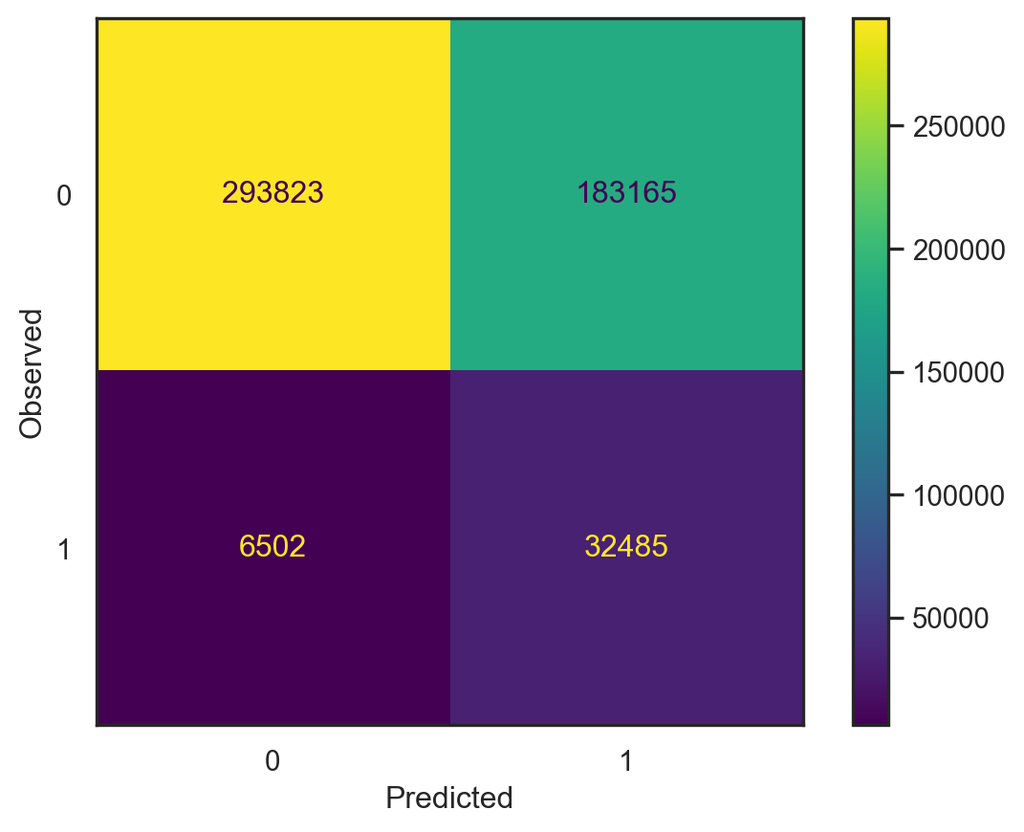

(a) Absolute counts

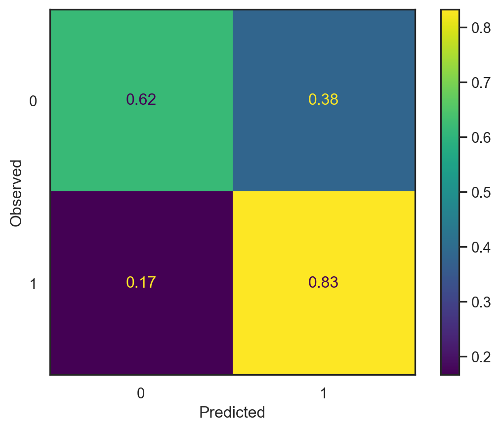

(b) True Class Success Rate

Figure 5: Confusion Matrix XGBoost model

```python
xgb_cm =  plot_cm(model_xgb, X_test_full, y_test, normalize=None)
xgb_cm_norm =  plot_cm(model_xgb, X_test_full, y_test, normalize='true')

xgb_cm
xgb_cm_norm
```

XGBoost showed good performance with a weighted F1-score of approximately 0.72 and a ROC-AUC of 0.788 on the test set. While the training ROC-AUC reached 0.801, the slight decrease in the test set suggests minor overfitting.

The model correctly identifies a large number of survivors (293,823 True Negatives) but generates a substantial number of False Positives (183,165). The number of False Negatives (6,502) is relatively low compared to the True Positives (32,485). This implies a recall of approximately 83.3%, showing that the model is effective at detecting most high-risk patients, missing only a small fraction of actual deaths.

### LightGBM Classifier

```python
start = time.time()

# define LightGBM model
model_lgb = lgb.LGBMClassifier(
  n_estimators=500, is_unbalance=True, random_seed=42,
  verbose=0
)

# fit LightGBM model
model_lgb.fit(X_train_full, y_train)
print(f"Time taken: {time.time() - start:.1f}s")
```

```
Time taken: 24.3s
```

```python
# print training results
print(f"LightGBM train weighted F1 score: {f1_score(y_train, model_lgb.predict(X_train_full), average="weighted"):.3f}")
print(f"LightGBM train ROC-AUC score: {roc_auc_score(y_train, model_lgb.predict_proba(X_train_full)[:,1]):.3f}")
```

```
LightGBM train weighted F1 score: 0.717
LightGBM train ROC-AUC score: 0.796
```

```python
start_time = time.time()

# predict
lgb_test_f1 = f1_score(y_test, model_lgb.predict(X_test_full), average='weighted')

# get proba and auc
lgb_test_proba = model_lgb.predict_proba(X_test_full)[:, 1]
lgb_test_auc = roc_auc_score(y_test, lgb_test_proba)
print(f"Time taken: {time.time() - start_time:.1f}s")
```

```
Time taken: 6.2s
```

```python
# print result
print(f"LightGBM test weighted F1-score: {lgb_test_f1:.3f}")
print(f"LightGBM test ROC-AUC score: {lgb_test_auc:.3f}")
```

```
LightGBM test weighted F1-score: 0.717
LightGBM test ROC-AUC score: 0.790
```

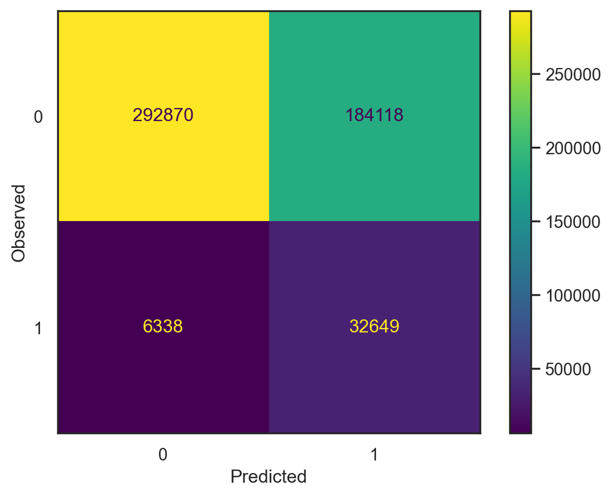

(a) Absolute counts

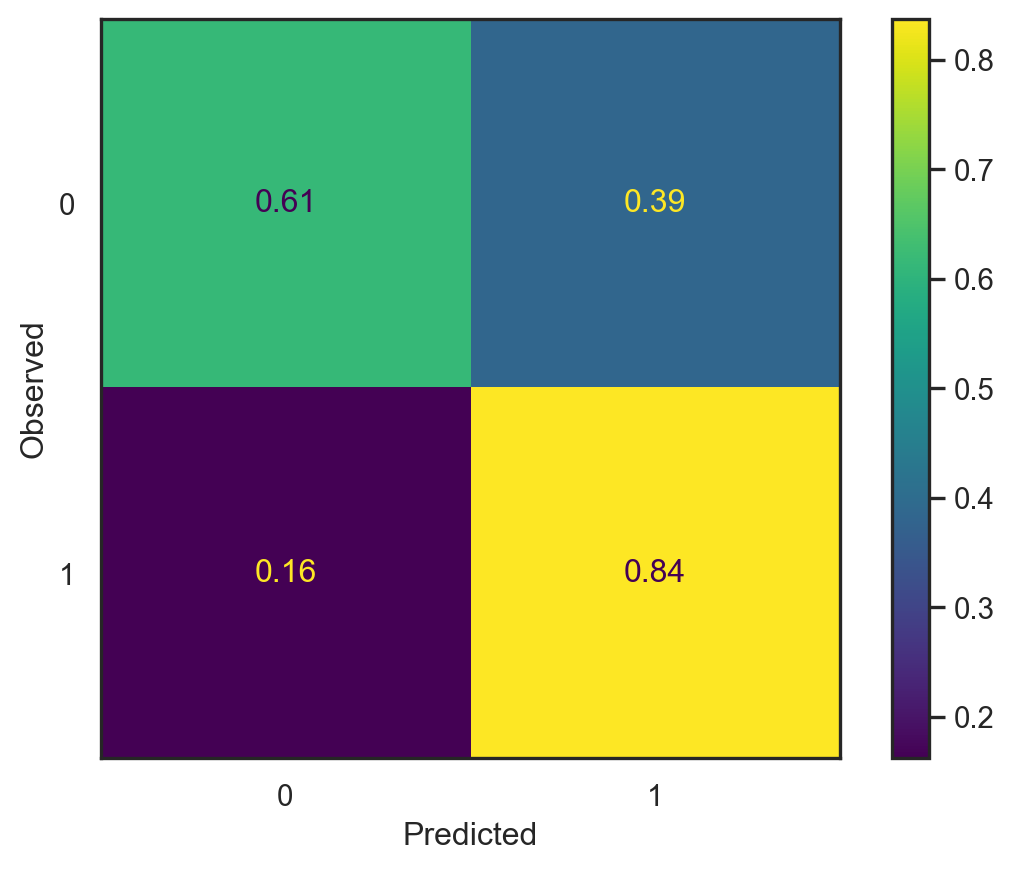

(b) True Class Success Rate

Figure 6: Confusion Matrix LightGBM model

```python
lgb_cm =  plot_cm(model_lgb, X_test_full, y_test, normalize=None)
lgb_cm_norm =  plot_cm(model_lgb, X_test_full, y_test, normalize='true')

lgb_cm
lgb_cm_norm
```

LightGBM delivered the best overall results, slightly outperforming XGBoost with a test ROC-AUC of 0.790. Notably, LightGBM showed higher stability between training (0.796) and testing. Although it increased the number of FP, the model detected 32,649 True Positives — identifying 164 more death cases than XGBoost.

### Random Forest Classifier

```python
start = time.time()

# define random forest model
model_rfc = RandomForestClassifier(
  n_estimators=200, max_depth=6, class_weight="balanced", random_state=42
)

# fit the model
model_rfc.fit(X_train_full, y_train)
print(f"Time taken: {(time.time() - start)/60:.1f}m")
```

```
Time taken: 7.6m
```

```python
# print training results
print(f"Random Forest train weighted F1-score: {f1_score(y_train, model_rfc.predict(X_train_full), average="weighted"):.3f}")
print(f"Random Forest train ROC-AUC score: {roc_auc_score(y_train, model_rfc.predict_proba(X_train_full)[:,1]):.3f}")
```

```
Random Forest train weighted F1-score: 0.724
Random Forest train ROC-AUC score: 0.778
```

```python
start_time = time.time()

# predict
rfc_test_f1 = f1_score(y_test, model_rfc.predict(X_test_full), average='weighted')

# get proba and auc
rfc_test_proba = model_rfc.predict_proba(X_test_full)[:, 1]
rfc_test_auc = roc_auc_score(y_test, rfc_test_proba)
print(f"Time taken: {time.time() - start_time:.1f}s")
```

```
Time taken: 18.8s
```

```python
# print result
print(f"Random Forest test weighted F1-score: {rfc_test_f1:.3f}")
print(f"Random Forest test ROC-AUC score: {rfc_test_auc:.3f}")
```

```
Random Forest test weighted F1-score: 0.724
Random Forest test ROC-AUC score: 0.777
```

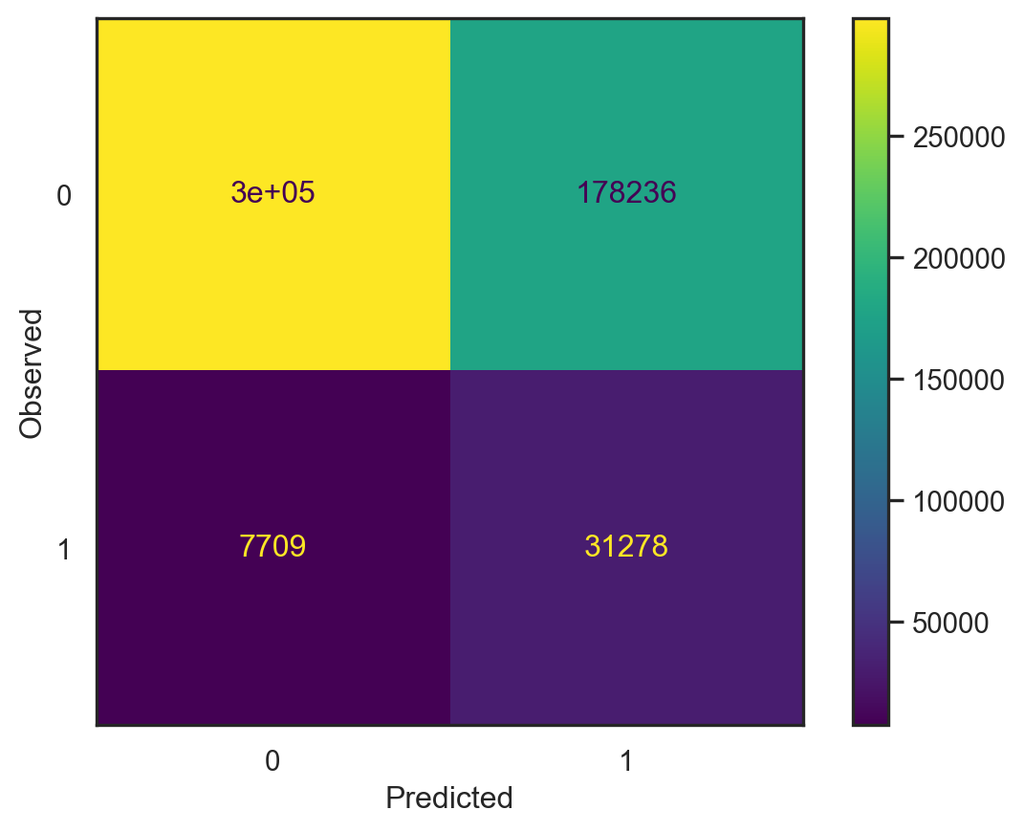

(a) Absolute counts

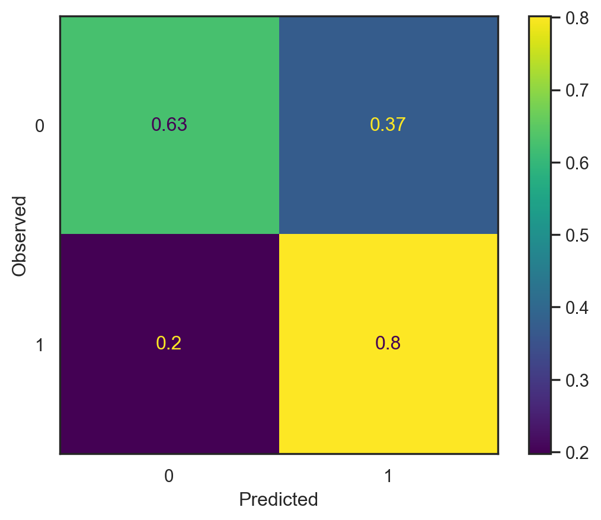

(b) True Class Success Rate

Figure 7: Confusion Matrix Random Forest model

```python
rfc_cm =  plot_cm(model_rfc, X_test_full, y_test, normalize=None)
rfc_cm_norm =  plot_cm(model_rfc, X_test_full, y_test, normalize='true')

rfc_cm
rfc_cm_norm
```

The Random Forest model achieved a test ROC-AUC of 0.777, with basicaly no gap between training and testing scores (0.778 vs 0.777). While highly consistent, its lower recall (80.2%) and higher number of False Negatives (7,709) suggest that its complexity prevents it from capturing the intricate patterns of mortality risk like the boosting algorithms. RF model had over 1000 TP less than LightGBM.

### Balanced Bagging Classifier

```python
start = time.time()

# define the model
model_bbc = BalancedBaggingClassifier(
  n_estimators=100, sampling_strategy="auto", random_state=42
)

# fit model
model_bbc.fit(X_train_full, y_train)
print(f"Time taken: {(time.time() - start)/60:.1f}m")
```

```
Time taken: 6.9m
```

```python
# print training results
print(f"BalancedBC train weighted F1-score: {f1_score(y_train, model_bbc.predict(X_train_full), average="weighted"):.3f}")
print(f"BalancedBC train ROC-AUC score: {roc_auc_score(y_train, model_bbc.predict_proba(X_train_full)[:,1]):.3f}")
```

```
BalancedBC train weighted F1-score: 0.726
BalancedBC train ROC-AUC score: 0.818
```

```python
start = time.time()

# predict
bbc_test_f1 = f1_score(y_test, model_bbc.predict(X_test_full), average="weighted")

# get proba and auc
bbc_test_proba = model_bbc.predict_proba(X_test_full)[:, 1]
bbc_test_auc = roc_auc_score(y_test, bbc_test_proba)
print(f"Time taken: {(time.time() - start)/60:.1f}m")
```

```
Time taken: 0.9m
```

```python
# print results
print(f"BalancedBC test weighted F1-score: {bbc_test_f1:.3f}")
print(f"BalancedBC test ROC-AUC score: {bbc_test_auc:.3f}")
```

```
BalancedBC test weighted F1-score: 0.720
BalancedBC test ROC-AUC score: 0.777
```

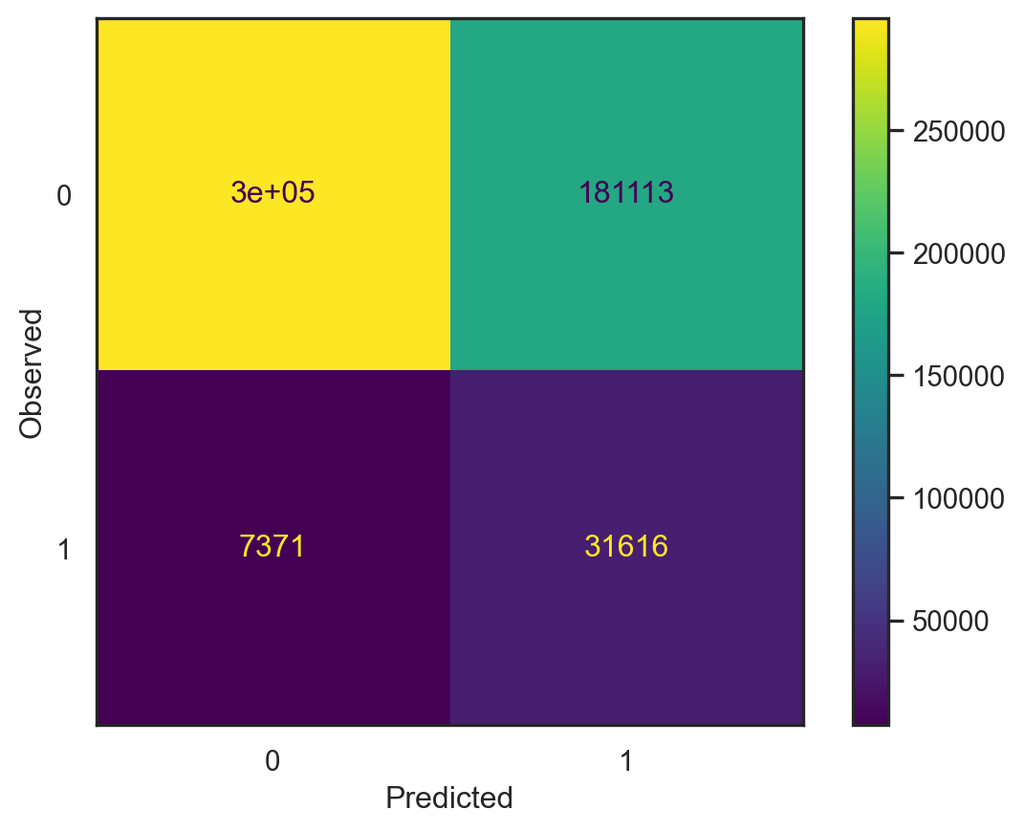

(a) Absolute counts

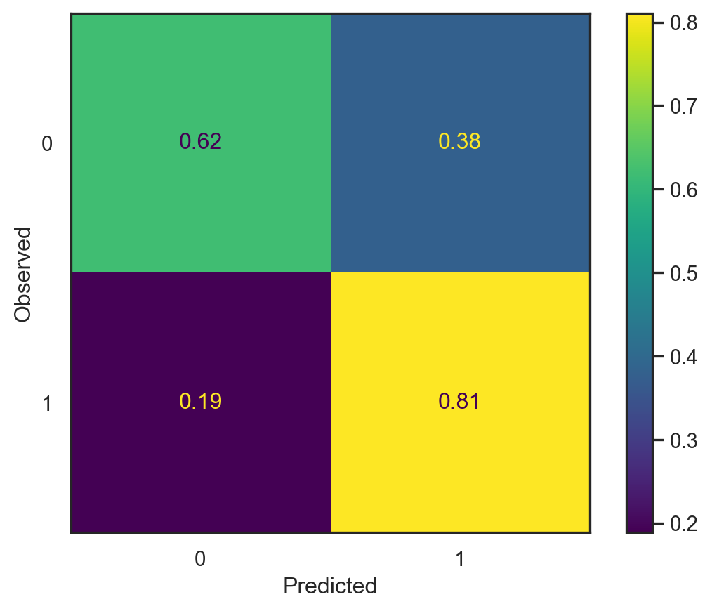

(b) True Class Success Rate

Figure 8: Confusion Matrix BalancedBC model

```python
bbc_cm =  plot_cm(model_bbc, X_test_full, y_test, normalize=None)
bbc_cm_norm =  plot_cm(model_bbc, X_test_full, y_test, normalize='true')

bbc_cm
bbc_cm_norm
```

BalancedBaggingClassifier (BalancedBC) achieved a slightly higher ROC-AUC on the training set but showed a significant drop in the test set. While it produced fewer FP than the boosting models, its inability to generalize led it to miss over 1000 additional real death cases compared to LightGBM, highlighting the limitations of internal undersampling for this dataset.

### Balanced Random Forest

```python
start = time.time()

# define the model
model_brf = BalancedRandomForestClassifier(
  n_estimators=200, sampling_strategy="auto", random_state=42
)

# fit model
model_brf.fit(X_train_full, y_train)
print(f"Time taken: {(time.time() - start)/60:.1f}m")
```

```
Time taken: 5.6m
```

```python
# print training results
print(f"BalancedRF train weighted F1-score: {f1_score(y_train, model_brf.predict(X_train_full), average="weighted"):.3f}")
print(f"BalancedRF train ROC-AUC score: {roc_auc_score(y_train, model_brf.predict_proba(X_train_full)[:,1]):.3f}")
```

```
BalancedRF train weighted F1-score: 0.711
BalancedRF train ROC-AUC score: 0.816
```

```python
start = time.time()

# predict
brf_test_f1 = f1_score(y_test, model_brf.predict(X_test_full), average="weighted")

# get proba and auc
brf_test_proba = model_brf.predict_proba(X_test_full)[:, 1]
brf_test_auc = roc_auc_score(y_test, brf_test_proba)
print(f"Time taken: {(time.time() - start)/60:.1f}m")
```

```
Time taken: 1.5m
```

```python
# print results
print(f"BalancedRF test weighted F1-score: {brf_test_f1:.3f}")
print(f"BalancedRF test ROC-AUC score: {brf_test_auc:.3f}")
```

```
BalancedRF test weighted F1-score: 0.705
BalancedRF test ROC-AUC score: 0.775
```

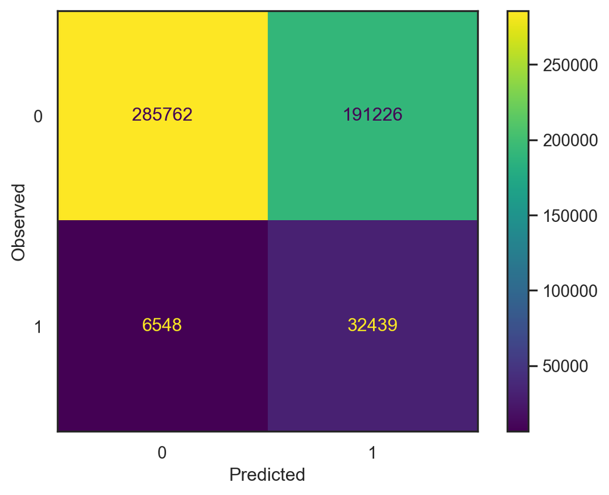

(a) Absolute counts

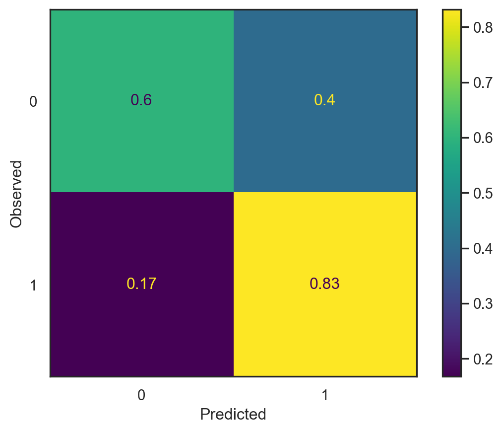

(b) True Class Success Rate

Figure 9: Confusion Matrix BalancedRF model

```python
brf_cm =  plot_cm(model_brf, X_test_full, y_test, normalize=None)
brf_cm_norm =  plot_cm(model_brf, X_test_full, y_test, normalize='true')

brf_cm
brf_cm_norm
```

Both BalancedBC and BalancedRandomForest (BalancedRF) suffered from “overfitting”, with training ROC-AUC values of 0.81 dropping to ~0.77 on the test set. While the BalancedRF identified a high number of real death cases (32,439), its overall ability to separate classes was inferior to the boosting models, resulting in a higher number of FP (~7000) than LightGBM.

Despite no big difference in the ROC-AUC score over the tested models, boosting algorithms outperformed the Bagging algorithms being LightGBM model the best one.

```python
# dict with all tested models proba
models = {
  "XGBoost": xgb_test_proba,
  "LightGBM": lgb_test_proba,
  "Random Forest": rfc_test_proba,
  "BalancedBC": bbc_test_proba,
  "BalancedRF": brf_test_proba
}
```

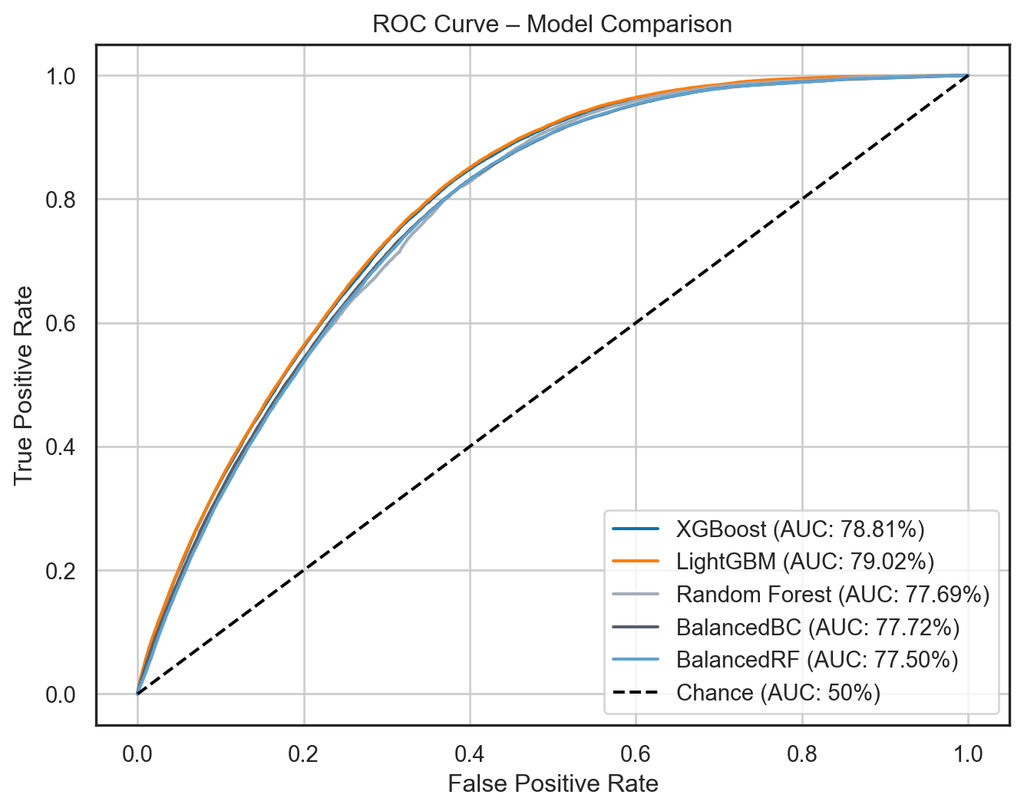

Figure 10: Roc curve of all avaliated models

```python
# plot roc curve
plt.figure(figsize=(8, 6))

for name, proba in models.items():
  fpr, tpr, _ = roc_curve(y_test, proba)
  auc = roc_auc_score(y_test, proba)
  plt.plot(fpr, tpr, label=f"{name} (AUC: {100*auc:.2f}%)")

# linha aleatória
plt.plot([0, 1], [0, 1], linestyle="--", color="black", label="Chance (AUC: 50%)")

plt.xlabel("False Positive Rate")
plt.ylabel("True Positive Rate")
plt.title("ROC Curve – Model Comparison")
plt.legend()
plt.grid(True)

plt.show()
```

Given that the objective of this project is to estimate the risk of in-hospital mortality rather than to rely on a fixed binary classification, the LightGBM model demonstrated the best probabilistic ranking (ROC-AUC: 0.79) and faster training, indicating better performance in distinguishing high-risk patients from low-risk patients.

Let’s look ate the feature importance oF the model.

```python
# get feature importance based on importance gain
feat_importances = pd.DataFrame({
    'feature': X_train_full.columns,
    'importance': model_lgb.booster_.feature_importance(importance_type="gain")
}).sort_values(by='importance', ascending=False)

# calculate cumulative importance
feat_importances["cum_importance"] = (
    feat_importances["importance"].cumsum() /
    feat_importances["importance"].sum()
)

feat_importances
```

|  | feature | importance | cum_importance |
| --- | --- | --- | --- |
| 0 | age | 3.730393e+06 | 0.570697 |
| 1 | disease_category | 1.399945e+06 | 0.784868 |
| 2 | procedure | 7.522788e+05 | 0.899956 |
| 3 | mean_days_by_disease | 2.504661e+05 | 0.938274 |
| 4 | mean_days_by_speciality | 2.069709e+05 | 0.969938 |
| 11 | big_region_name_Norte | 3.616427e+04 | 0.975470 |
| 9 | big_region_name_Sudeste | 3.324519e+04 | 0.980556 |
| 5 | gender_Male | 3.061804e+04 | 0.985240 |
| 8 | big_region_name_Sul | 2.724872e+04 | 0.989409 |
| 7 | big_region_name_Nordeste | 2.305142e+04 | 0.992936 |
| 16 | bed_speciality_buco_maxilo_facial | 1.565511e+04 | 0.995331 |
| 10 | big_region_name_Centro_Oeste | 7.292797e+03 | 0.996446 |
| 14 | bed_speciality_cirurgia_geral | 6.722079e+03 | 0.997475 |
| 18 | bed_speciality_few_cases | 6.322007e+03 | 0.998442 |
| 12 | complexity_media_complexidade | 3.418239e+03 | 0.998965 |
| 6 | gender_Female | 3.110918e+03 | 0.999441 |
| 15 | bed_speciality_cirurgico_diagnostico_terapeutico | 2.571577e+03 | 0.999834 |
| 20 | bed_speciality_rare_cases | 9.268244e+02 | 0.999976 |
| 19 | bed_speciality_zero_risk | 1.006723e+02 | 0.999991 |
| 13 | complexity_internacao | 5.598848e+01 | 1.000000 |
| 17 | bed_speciality_ginecologia | 0.000000e+00 | 1.000000 |

Feature importance shows that age alone explains more than half of the model’s total gain. Also, 99% of the model gain is explained by half of the features. Since the overall number of features is already small, we proceed with the full model rather than attempting feature selection or dimensionality reduction.

### Tuning

At this point we can try tuning the LightGBM model for improve its ROC-AUC performance.

```python
start = time.time()

# define model
model = lgb.LGBMClassifier(is_unbalance=True, random_seed=42, verbose=-1)

# define parameters
param_grid = {
  'n_estimators': [500, 800],
  'learning_rate': [0.03, 0.05, 0.08],
  'num_leaves': [15, 31, 63],
  'max_depth': [4, 6, 8],
  'min_child_samples': [20, 50, 100],
  'subsample': [0.5, 0.8, 1.0],
  'colsample_bytree': [0.5, 0.8, 1.0],
  'reg_alpha': [0.01, 0.1, 1.0],
  'reg_lambda': [0.01, 0.1, 1.0]
}

# random search
random_search = RandomizedSearchCV(
  estimator=model,
  param_distributions=param_grid,
  n_iter=20,
  cv=3,
  scoring='roc_auc',
  verbose=0,
  random_state=42
)

# fit random search
random_search.fit(X_train_full, y_train)
print(f"Time taken: {(time.time() - start)/60:.1f}m")
```

```
Time taken: 30.1m
```

```python
print("Tuned model best score:")
random_search.best_score_
```

```
Tuned model best score:
```

```
np.float64(0.7904903109535951)
```

```python
print("Tuned model best parameters:")
random_search.best_params_
```

```
Tuned model best parameters:
```

```
{'subsample': 0.8,
 'reg_lambda': 0.01,
 'reg_alpha': 0.1,
 'num_leaves': 63,
 'n_estimators': 500,
 'min_child_samples': 100,
 'max_depth': 8,
 'learning_rate': 0.03,
 'colsample_bytree': 0.8}
```

```python
start = time.time()

# get best estimator
tuned_model = random_search.best_estimator_

# predict
tuned_f1 = f1_score(y_test, tuned_model.predict(X_test_full), average="weighted")
tuned_auc = roc_auc_score(y_test, tuned_model.predict_proba(X_test_full)[:, 1])
print(f"Time taken: {time.time() - start:.1f}s")
```

```
Time taken: 11.9s
```

```python
# print results
print(f"Tuned model weighted F1-score: {tuned_f1:.3f}")
print(f"Tuned model ROC-AUC score: {tuned_auc:.3f}")
```

```
Tuned model weighted F1-score: 0.716
Tuned model ROC-AUC score: 0.791
```

Hyperparameter optimization suggests that we have reached the inherent efficiency of the current dataset. The tuning resulted in marginal improvements in ROC-AUC, indicating that the baseline LightGBM model was already close to optimal performance given the feature set.

Given the large dataset size, the minimal gains from tuning don’t justify the additional complexity and computational cost.

### Final model

The base LightGBM model demonstrates better overall performance. Therefore, is the most appropriate choice for the primary objective of estimating the risk of in-hospital mortality.

```python
# define features and target set
X_oot = oot[features]
y_oot = oot[target]
```

```python
# define the final pipeline
final_pipeline = Pipeline([
  ("preprocess", preprocess_pipeline),
  ("final model", model_lgb)
])
```

```python
start = time.time()

# predict oot
y_pred_oot = final_pipeline.predict(X_oot)
y_proba_oot = final_pipeline.predict_proba(X_oot)[:, 1]

# get scores
f1_ooc = f1_score(y_oot, y_pred_oot, average="weighted")
auc_ooc = roc_auc_score(y_oot, y_proba_oot)
print(f"Time taken: {time.time() - start:.1f}s")
```

```
Time taken: 17.3s
```

```python
# print results
print("Model weighted F1-score:", f1_ooc)
print("Model ROC-AUC score:", auc_ooc)
```

```
Model weighted F1-score: 0.712487453489581
Model ROC-AUC score: 0.7891837261159305
```

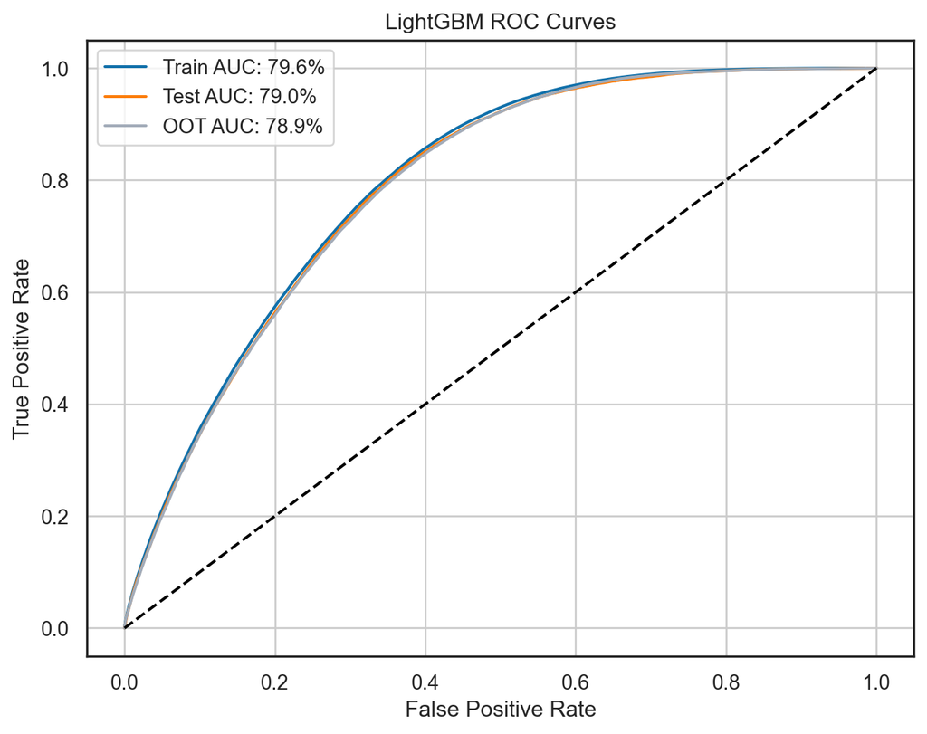

Figure 11: Roc curves of LightGBM train/test/oot set

```python
# get lgb train proba and auc
lgb_train_proba = model_lgb.predict_proba(X_train_full)[:, 1]
lgb_train_auc = roc_auc_score(y_train, lgb_train_proba)

# get roc curve
roc_train = roc_curve(y_train, lgb_train_proba)
roc_test = roc_curve(y_test, lgb_test_proba)
roc_oot = roc_curve(y_oot, y_proba_oot)

# plot roc curve
plt.figure(figsize=(8, 6))

plt.plot(roc_train[0], roc_train[1])
plt.plot(roc_test[0], roc_test[1])
plt.plot(roc_oot[0], roc_oot[1])
plt.plot([0, 1], [0, 1], linestyle="--", color="black", label="Chance")
plt.xlabel("False Positive Rate")
plt.ylabel("True Positive Rate")
plt.title("LightGBM ROC Curves")
plt.legend([
  f"Train AUC: {100*lgb_train_auc:.1f}%",
  f"Test AUC: {100*lgb_test_auc:.1f}%",
  f"OOT AUC: {100*auc_ooc:.1f}%"
  ])
plt.grid(True)
```

#### SHAP values

```python
# get explainer and shap values
explainer = shap.TreeExplainer(model_lgb)
shap_values = explainer.shap_values(preprocess_pipeline.transform(X_oot))
```

Since categorical variables were transformed into multiple dummie features through encoding, SHAP values can be aggregated back to their original feature groups by summing the contributions of all encoded components, preserving the total contribution of each original feature.

```python
# make a df with the shap values
feature_names = model_lgb.feature_name_
shap_df = pd.DataFrame(
  shap_values,
  columns=feature_names
)

# map encoded features back to their original feature groups
feature_map = {}

for col in shap_df.columns:
  if col.startswith("mean_days_by_"):
    original = col
  elif "_" in col:
    original = col.split("_", 1)[0]
  else:
    original = col
  feature_map.setdefault(original, []).append(col)

# agg and sum SHAP values at the original feature level
shap_agg = pd.DataFrame()
for feature, cols in feature_map.items():
  shap_agg[feature] = shap_df[cols].sum(axis=1)

# rename features name
shap_agg = shap_agg.rename(columns={
  "age": "Age",
  "procedure": "Procedure",
  "gender": "Sex",
  "big": "Region",
  "complexity": "Complexity",
  "bed": "Bed speciality",
  "disease": "Disease category",
  "mean_days_by_speciality": "Mean hosp. days by speciality",
  "mean_days_by_disease": "Mean hosp. days by disease",
})

shap_agg
```

|  | Age | Disease category | Procedure | Mean hosp. days by disease | Mean hosp. days by speciality | Sex | Region | Complexity | Bed speciality |
| --- | --- | --- | --- | --- | --- | --- | --- | --- | --- |
| 0 | 0.299462 | 0.881287 | 0.507691 | 0.141502 | 0.169743 | 0.066796 | 0.058312 | -0.589394 | 0.155946 |
| 1 | -2.122267 | -0.528679 | -2.325423 | -0.112716 | -0.594150 | 0.009043 | -0.320755 | 0.007736 | 0.083412 |
| 2 | 0.057531 | 0.664190 | 0.208442 | -0.006746 | 0.117598 | -0.073471 | 0.017185 | 0.004060 | 0.003963 |
| 3 | -1.305848 | 0.528155 | -4.050236 | 0.326215 | -2.710659 | -0.041137 | 0.198616 | 0.004608 | -0.747438 |
| 4 | -1.784875 | -0.387229 | 0.143356 | -0.298710 | 0.340971 | 0.412764 | 0.095917 | 0.000103 | 0.015639 |
| ... | ... | ... | ... | ... | ... | ... | ... | ... | ... |
| 553881 | 0.493412 | 0.814873 | -0.469494 | 0.292317 | 0.112948 | 0.040648 | 0.112791 | 0.001521 | 0.021151 |
| 553882 | 0.910143 | -0.342059 | 0.176176 | -0.071815 | 0.108814 | 0.040997 | -0.118578 | 0.005513 | 0.005148 |
| 553883 | 0.887839 | 0.549625 | 0.344471 | 0.160613 | 0.088546 | -0.013924 | 0.051871 | 0.004122 | 0.006719 |
| 553884 | 0.205428 | 0.659944 | 0.362428 | 0.103223 | 0.099615 | 0.024747 | 0.060190 | 0.002800 | 0.003967 |
| 553885 | 0.187430 | -0.631532 | -0.571296 | -0.010911 | 0.215990 | 0.068584 | 0.047688 | 0.005593 | 0.056130 |

553886 rows × 9 columns

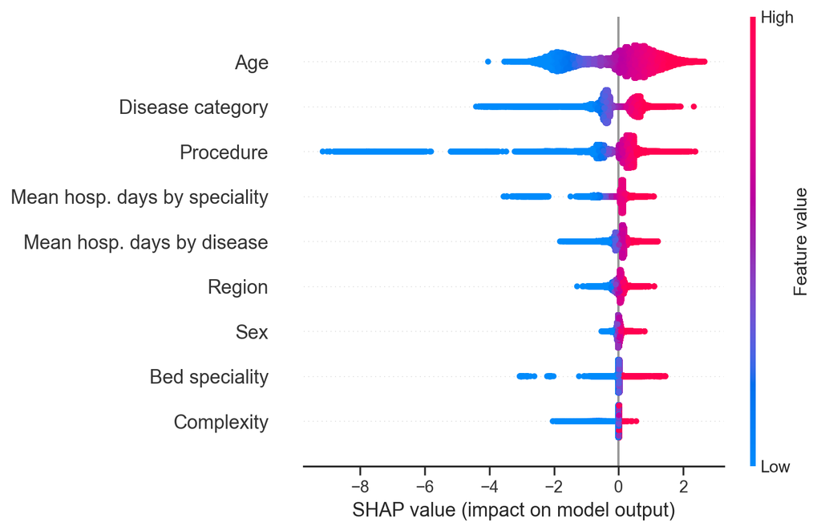

Figure 12: SHAP Summary (global feature importance)

```python
# summary of the predictions
fig_shap_summary = plt.figure(figsize=(10, 8))
shap.summary_plot(
  shap_agg.values,
  features=shap_agg,
  feature_names=shap_agg.columns,
  show=False
)
plt.tight_layout()
```

Features are ranked by overall importance, with `age`, `disease_category`, and `procedure` showing the largest contributions to the predictions. For all variables, higher feature values tend to be associated with positive SHAP values, increasing the predicted risk, while lower values are predominantly associated with negative SHAP values, reducing the predicted risk. Older individuals exhibit a higher predicted risk of mortality, and procedures and disease categories with higher historical mean mortality rates increase the model’s risk prediction, whereas those associated with lower historical mean mortality rates tend to reduce it.

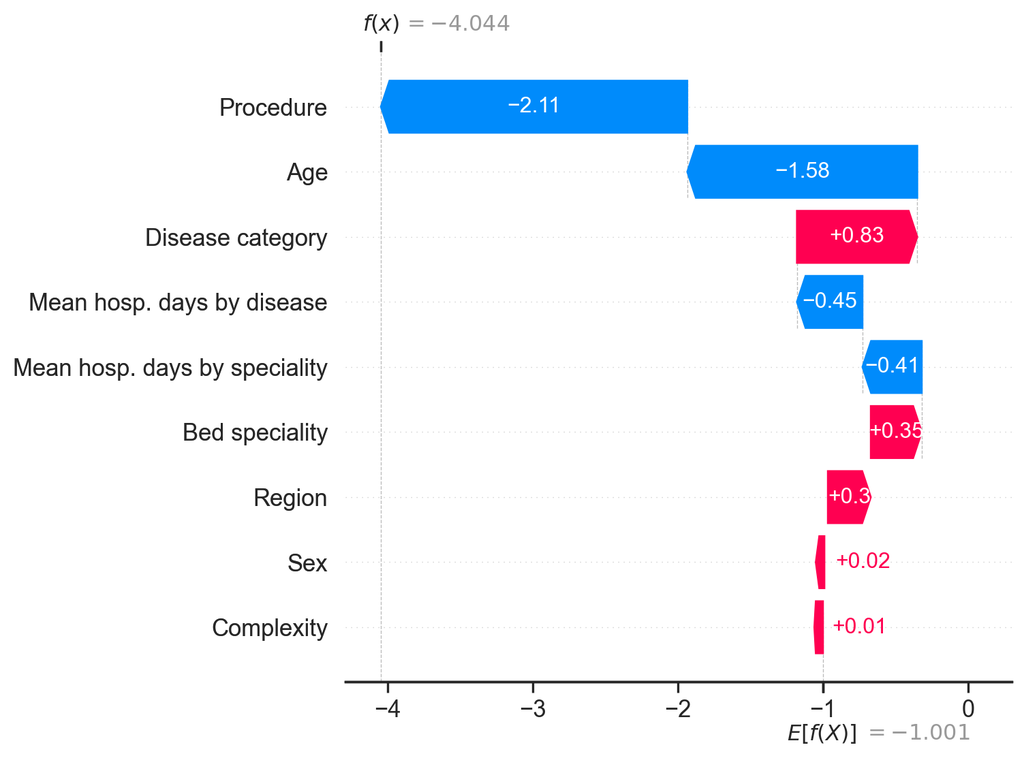

Figure 13: SHAP Waterfall (individual feature importance)

```python
# individual prediction
plt.figure(figsize=(10, 8))
shap.plots.waterfall(
  shap.Explanation(
    values=shap_agg.iloc[29].values,
    base_values=explainer.expected_value,
    feature_names=shap_agg.columns
  ), show=False
)
plt.tight_layout()
```

Waterfall plot shows the contribution of individual features to the model prediction for a specific hospitalization. For this individual (29), we can see that the largest negative contributions come from `procedure` (−2.11) and `age` (−1.58), which substantially reduce the predicted risk relative to the baseline. `Disease_category` acts in the opposite direction, contributing positively (+0.83) to the prediction.

At last, instead of using a fixed 0.5 decision threshold, which could be inadequate under class imbalance, predicted probabilities are used to stratify individuals into clinically meaningful risk categories.

```python
# oot transformed
final_oot = oot.drop(columns=["death_flag", "total_hosp_days"], axis=1).copy()

# create new col with the probas of death
final_oot["risk"] = y_proba_oot

# create new col with the class risk definitions
final_oot["risk_class"] = np.select(
  [
    final_oot["risk"] < 0.20,
    (final_oot["risk"] >= 0.20) & (final_oot["risk"] < 0.40),
    (final_oot["risk"] >= 0.40) & (final_oot["risk"] < 0.60),
    final_oot["risk"] >= 0.60
  ],
  [
    "Low risk",
    "Moderate risk",
    "High risk",
    "Imminent risk"
  ],
  default="Unknown"
)
```

```python
final_oot.head()
```

|  | id_hospitalization | year | month | big_region_name | gender | age | disease_category | bed_speciality | complexity | procedure | risk | risk_class |
| --- | --- | --- | --- | --- | --- | --- | --- | --- | --- | --- | --- | --- |
| 0 | 2624103299686 | 2024 | 9 | Nordeste | Male | 55 | Doenças Cerebrovasculares | buco maxilo facial | internacao | embolizacao de aneurisma cerebral menor do que... | 0.665965 | Imminent risk |
| 1 | 2624108075138 | 2024 | 9 | Nordeste | Male | 4 | Gastroenterites Infecciosas e complicações | cirurgico/diagnostico/terapeutico | media complexidade | diagnostico e/ou atendimento de urgencia em cl... | 0.001002 | Low risk |
| 2 | 3324106904701 | 2024 | 9 | Sudeste | Female | 49 | Úlcera gastrointestinal | cirurgia geral | media complexidade | tratamento de outras doencas do aparelho diges... | 0.497850 | High risk |
| 3 | 3324107461092 | 2024 | 9 | Sudeste | Female | 27 | Pneumonias bacterianas | cardiologia | media complexidade | tratamento de intercorrencias clinicas na grav... | 0.000151 | Low risk |
| 4 | 2124108231575 | 2024 | 11 | Nordeste | Male | 24 | Infecção no Rim e Trato Urinário | cirurgia geral | media complexidade | tratamento de outras doencas do aparelho urinario | 0.078463 | Low risk |

# Summary of results

Among the evaluated models, the LightGBM classifier achieved the best overall performance and was therefore selected as the final model. Given the class imbalance and the focus on risk classification, ROC-AUC was the primary metric as it measures how well the model separates low- from high-risk patients based on predicted probabilities.

- **Overall performance**: LightGBM achieved the highest ROC-AUC score of 0.79 across the test set.
- **Interpretability**: SHAP values highlited `age`, `disease_category` and `procedure` were the features with the biggest contributions to the model’s predictions.
- **Efficiency**: The model showed the best computational performance (faster training time) for the largest dataset.